# Week 7 companion - Modal forecasting of a real cylinder wake

**Development companion:** local Run All is tested; main-branch Colab becomes available only after merge. No new release or DOI is implied.

Compare projected DMD with a freshly trained nonlinear modal baseline, persistence, and POD representation floors. Prerequisites: POD, complex eigenvalues and Week 7 LBM; allow 60-75 minutes. Lecture: `lectures/week07_modal_forecasting.pdf`.

All fields come from earlier author-generated CFD, not synthetic wake formulas. The 12-node-per-diameter LBM is educational, not grid independent. This wake has vortical structures but no shock. DMD forecasts a field; it does not identify cores.

```python
# FLOWMLLAB_COLAB_BOOTSTRAP_V1
# In Colab this cell obtains the complete repository and installs the tested package.
# In a local checkout it leaves the active environment and working directory unchanged.
from pathlib import Path as _FlowMLLabPath
import os as _flowmllab_os
import subprocess as _flowmllab_subprocess
import sys as _flowmllab_sys

if "google.colab" in _flowmllab_sys.modules or _flowmllab_os.environ.get("COLAB_RELEASE_TAG"):
    _flowmllab_root = _FlowMLLabPath("/content/FlowMLLab")
    if not (_flowmllab_root / ".git").is_dir():
        _flowmllab_subprocess.run(
            [
                "git", "clone", "--depth", "1",
                "https://github.com/Ehsan-Roohi/FlowMLLab.git", str(_flowmllab_root),
            ],
            check=True,
        )
    _flowmllab_subprocess.run(
        [
            _flowmllab_sys.executable, "-m", "pip", "install", "-q", "-e",
            f"{_flowmllab_root}[test]",
        ],
        check=True,
    )
    _flowmllab_notebook_dir = _flowmllab_root / "notebooks/week07"
    _flowmllab_os.chdir(_flowmllab_notebook_dir)
    for _flowmllab_path in (_flowmllab_root, _flowmllab_notebook_dir):
        if str(_flowmllab_path) not in _flowmllab_sys.path:
            _flowmllab_sys.path.insert(0, str(_flowmllab_path))
    print("FlowMLLab ready:", _flowmllab_root)

from pathlib import Path
import sys, hashlib, tempfile
ROOT = next(p for p in (Path.cwd(), *Path.cwd().parents) if (p/'flowmllab/modal_experiments.py').is_file())
sys.path.insert(0, str(ROOT))
sys.path.insert(0, str(ROOT/'qa'))
import numpy as np
import pandas as pd
import matplotlib.pyplot as plt
from IPython.display import display, Image
from threadpoolctl import threadpool_limits
from flowmllab.modal_tools import *
from flowmllab.field_metrics import field_metrics, temporal_spectrum
from flowmllab.modal_experiments import PLAN, load_cases, forecast_experiment, sensor_experiment
from run_modal_labs import figures
tracked_evidence = [p for folder in ('data/modal_labs','results/modal_labs') for p in (ROOT/folder).rglob('*') if p.is_file()]
before = {str(p): hashlib.sha256(p.read_bytes()).hexdigest() for p in tracked_evidence}
cases = load_cases(ROOT/'data/modal_labs')
display(PLAN)
print('Checksummed author LBM; previously inspected cases, not a new blind CFD study.')
```

```
Checksummed author LBM; previously inspected cases, not a new blind CFD study.
```

```
{'forecast': {'case': 110,
  'train': [0, 160],
  'validation': [160, 210],
  'test': [210, 281],
  'dmd_ranks': [2, 4, 6, 8],
  'sindy_rank': 2,
  'sindy_thresholds': [0.01, 0.05, 0.1],
  'sindy_degree': 3,
  'sindy_window': 4,
  'mlp_rank': 8,
  'mlp_history': 4,
  'mlp_hidden': [32, 32],
  'mlp_seed': 17,
  'mlp_max_iter': 1500,
  'selection': 'Minimum validation field relative L2; no reset at test boundary'},
 'sensors': {'train': [90, 110],
  'validation': 100,
  'test': 105,
  'rank': 8,
  'budgets': [8, 16, 32],
  'noise_fraction': 0.01,
  'seeds': [10, 11, 12, 13, 14],
  'selection': 'Smallest budget with mean optimized validation L2 <= 0.05; otherwise minimum validation L2'},
 'scope': 'Previously inspected coarse author LBM; educational ROI, not grid-independent CFD or blind research.'}
```

## 1. Derive and test the row-vector convention

For training POD rows $a_k$, let $X=[a_0;\ldots;a_{m-2}]$ and $Y=[a_1;\ldots;a_{m-1}]$. Solve $A=X^\dagger Y$, so $a_{k+1}=a_kA$. Reconstruct with the frozen training mean and basis. For eigenvalue $\lambda$, $f=\arg(\lambda)/(2\pi\Delta t)$ and $\sigma=\log|\lambda|/\Delta t$. Frequency is subject to sampling and the principal logarithm branch.

Verify a known oscillator before interpreting wake eigenvalues. Its angular frequency is 2, so cycles per unit time must be $1/\pi$.

```python
dt = .02
t = np.arange(400)*dt
oscillator = np.column_stack((np.cos(2*t), np.sin(2*t)))
operator = fit_dmd(oscillator[:200])
assert np.allclose(rollout_dmd(operator, oscillator[199], 200), oscillator[200:], atol=1e-12)
assert np.isclose(max(m['frequency'] for m in dmd_modes(operator,dt)), 1/np.pi)
display(pd.DataFrame(dmd_modes(operator,dt)))
```

|  | real | imag | frequency | growth_rate |
| --- | --- | --- | --- | --- |
| 0 | 0.9992 | 0.039989 | 0.31831 | 0.0 |
| 1 | 0.9992 | -0.039989 | -0.31831 | 0.0 |

## 2. Forecast, do not assimilate the answer

Re110 vorticity: training frames [0,160), validation [160,210), test [210,281). Fit centered POD only on training. Choose DMD rank among 2/4/6/8 by validation field error. Initialize at frame159 and advance through both held windows without resetting. This tests future time in one case, not a new Reynolds number.

The fresh MLP uses eight POD coordinates, four-frame history, two 32-unit tanh layers and fixed seed17. Scaling and supervised pairs use training only. It has more initial history than one-state DMD; report that distinction. Persistence repeats the last training field; the mean repeats the training mean. Full-field POD projections see target fields and are oracle floors, not forecasts. Do not compare to archived phase-decoder results with different information/splits.

```python
# Fresh CPU fits, not cached retained predictions. Limit BLAS threads for reproducibility.
with threadpool_limits(limits=1):
    forecast, predictions = forecast_experiment(cases)
    sensing, examples = sensor_experiment(cases)
scratch = Path(tempfile.mkdtemp(prefix='flowmllab-modal-'))
figures(scratch, cases, forecast, predictions, sensing, examples)
print('Exploratory figure output:', scratch)
```

```
Exploratory figure output: /tmp/flowmllab-modal-rknq74eq
```

```
Validation-selected DMD: DMD-r8
```

|  | validation_l2 | test_l2 | worst_test_frame |
| --- | --- | --- | --- |
| DMD-r2 | 0.361177 | 0.360920 | 0.378263 |
| DMD-r4 | 0.253501 | 0.254192 | 0.285334 |
| DMD-r6 | 0.105865 | 0.105657 | 0.112187 |
| DMD-r8 | 0.064572 | 0.064368 | 0.072415 |
| MLP-r8 | 0.054654 | 0.055384 | 0.057261 |
| persistence | 1.199391 | 1.131266 | 1.570491 |
| training-mean | 0.839987 | 0.837722 | 0.864326 |
| POD-r2-oracle | 0.360071 | 0.359586 | 0.376346 |
| POD-r8-oracle | 0.054512 | 0.054519 | 0.055918 |
| SINDy-0.01 | 0.360075 | 0.359620 | 0.376388 |
| SINDy-0.1 | 0.375108 | 0.436316 | 0.482826 |

```
{'warnings': [],
 'training_one_step_coefficient_mse': 2.5368499882973887e-06,
 'validation': {'relative_l2': 0.05465438053253217,
  'rmse': 0.034425295503138574,
  'maximum_absolute_error': 0.3284463998876026,
  'worst_frame_relative_l2': 0.05613917912059558,
  'zero_reference_frames': 0,
  'mean_absolute_scalar_integral_error': 0.0045555641075553256,
  'edge_relative_l2': 0.009004090864270826},
 'test': {'relative_l2': 0.055384248361283014,
  'rmse': 0.03486677847832432,
  'maximum_absolute_error': 0.3309247920998755,
  'worst_frame_relative_l2': 0.057260899459261126,
  'zero_reference_frames': 0,
  'mean_absolute_scalar_integral_error': 0.008710174317692259,
  'edge_relative_l2': 0.010054462444759974}}
```

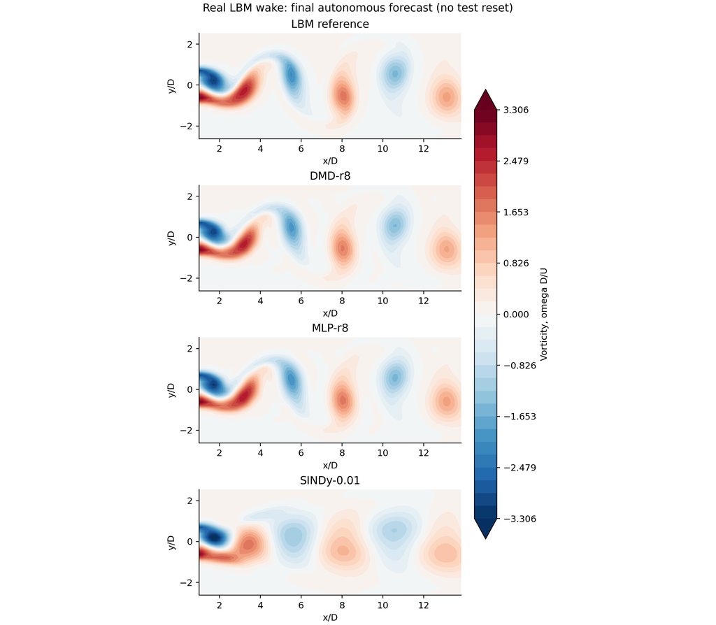

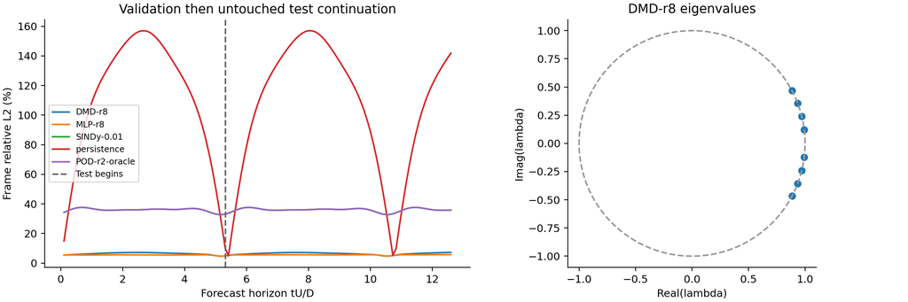

```python
print('Validation-selected DMD:', forecast['selected_dmd'])
display(pd.DataFrame({k:{'validation_l2':v['validation']['relative_l2'],
    'test_l2':v['test']['relative_l2'], 'worst_test_frame':v['test']['worst_frame_relative_l2']}
    for k,v in forecast['methods'].items()}).T)
display(forecast['methods']['MLP-r8'])
display(Image(filename=str(scratch/'forecast_fields.png')))
display(Image(filename=str(scratch/'forecast_audit.png')))
```

## 3. A frequency estimate is not a resolution guarantee

The source full-history force Strouhal is a diagnostic only; it was never used to train or select a model. Inspect all selected-DMD eigenvalues and distinguish wake modes, harmonics and possible box/acoustic modes. Do not automatically declare the largest frequency to be shedding.

At a geometrically selected probe near (x/D,y/D)=(4,0.5), compare mean-removed, Hann-windowed one-sided temporal spectra. Report the actual FFT spacing and phase error at the reference peak. The test window is only about 7.40 D/U, giving spacing about 0.135 U/D: too short for a precise Strouhal measurement. A model-based eigenfrequency does not improve the raw sampling resolution.

The Week 5 SINDy result is also retained, including failed candidates. Its rank-two field limitation is not evidence that all sparse dynamics fail.

```python
selected = forecast['selected_dmd']
display(pd.DataFrame(forecast['methods'][selected]['modes']))
print('Full-history force Strouhal (diagnostic only):', forecast['source_full_history_strouhal_diagnostic_only'])
print('Test duration:', forecast['test_duration'])
display(pd.DataFrame(forecast['spectra']).T)
display(pd.DataFrame(forecast['sindy_candidates']).T)
```

```
Full-history force Strouhal (diagnostic only): 0.1856558194376204
Test duration: 7.395833333333165
```

|  | real | imag | frequency | growth_rate |
| --- | --- | --- | --- | --- |
| 0 | 0.883978 | 0.467299 | 0.742996 | -0.001035 |
| 1 | 0.883978 | -0.467299 | -0.742996 | -0.001035 |
| 2 | 0.992639 | 0.121175 | 0.185597 | 0.000072 |
| 3 | 0.992639 | -0.121175 | -0.185597 | 0.000072 |
| 4 | 0.934283 | 0.356517 | 0.556975 | -0.000056 |
| 5 | 0.934283 | -0.356517 | -0.556975 | -0.000056 |
| 6 | 0.970582 | 0.240653 | 0.371347 | -0.000272 |
| 7 | 0.970582 | -0.240653 | -0.371347 | -0.000272 |

|  | frequency_resolution | reference_peak | predicted_peak | power_spectrum_relative_l2 | phase_error_at_reference_peak |
| --- | --- | --- | --- | --- | --- |
| DMD-r2 | 0.135211 | 0.135211 | 0.135211 | 0.511609 | 0.021639 |
| DMD-r4 | 0.135211 | 0.135211 | 0.135211 | 0.122233 | 0.004654 |
| DMD-r6 | 0.135211 | 0.135211 | 0.135211 | 0.086459 | 0.004627 |
| DMD-r8 | 0.135211 | 0.135211 | 0.135211 | 0.053257 | -0.004447 |
| MLP-r8 | 0.135211 | 0.135211 | 0.135211 | 0.006824 | -0.009404 |
| persistence | 0.135211 | 0.135211 | NaN | 1.000000 | NaN |
| training-mean | 0.135211 | 0.135211 | NaN | 1.000000 | NaN |
| POD-r2-oracle | 0.135211 | 0.135211 | 0.135211 | 0.541077 | 0.032686 |
| POD-r8-oracle | 0.135211 | 0.135211 | 0.135211 | 0.005185 | -0.000127 |
| SINDy-0.01 | 0.135211 | 0.135211 | 0.135211 | 0.542210 | 0.039583 |
| SINDy-0.1 | 0.135211 | 0.135211 | 0.135211 | 0.549573 | 0.420683 |

|  | threshold | equations | active_terms | status | validation_l2 | test_status | test_reason |
| --- | --- | --- | --- | --- | --- | --- | --- |
| SINDy-0.01 | 0.01 | [0.116625*1 + -0.0902163*z1 + -0.94372*z2 + -0... | 18 | ok | 0.360075 | ok | NaN |
| SINDy-0.05 | 0.05 | [-2.05699*z2 + 0.454383*z1^2 z2 + 0.44883*z2^3... | 10 | ok | 0.374168 | failed | Sparse ODE rollout failed/diverged; no clippin... |
| SINDy-0.1 | 0.1 | [-2.05699*z2 + 0.454383*z1^2 z2 + 0.44883*z2^3... | 4 | ok | 0.375108 | ok | NaN |

## A shared metric contract (PDEBench-inspired, not identical scores)

Report $\|q-\hat q\|_{2,w}/\|q\|_{2,w}$, area-weighted RMSE, maximum error, worst-frame relative error, ROI-edge error, and error of the supplied scalar integral. An ROI edge is **not a physical wall**. An integral of vorticity or velocity is **not automatically mass conservation**. Declare weights, units and geometry. For zero reference norm, relative error is undefined (`None`), not epsilon-regularized.

Test a known offset before trusting the CFD score: adding one to a field of two must give relative L2 = 0.5 and RMSE = 1. With 20 cells of area 0.25, the absolute scalar-integral error must be 5. These are numerical identities, not fitted tolerances.

```python
truth = np.full((3,4,5), 2.0)
metrics = field_metrics(truth+1, truth, np.full((4,5), .25))
assert np.isclose(metrics['relative_l2'], .5)
assert np.isclose(metrics['rmse'], 1)
assert np.isclose(metrics['mean_absolute_scalar_integral_error'], 5)
assert field_metrics(np.ones_like(truth), 0*truth)['relative_l2'] is None
display(metrics)
```

```
{'relative_l2': 0.5,
 'rmse': 1.0,
 'maximum_absolute_error': 1.0,
 'worst_frame_relative_l2': 0.5,
 'zero_reference_frames': 0,
 'mean_absolute_scalar_integral_error': 5.0}
```

## 4. Interpret and extend without changing the retained test

Explain the gap between the eight-mode POD oracle and DMD. Distinguish discretization error, representation error and autonomous dynamics error. Why would resetting to a true state at frame210 make the forecast easier? Propose a new-Re case and a longer-duration test, with thresholds frozen before seeing either. For a noise-robust DMD study, add a declared observation-noise protocol and a matched robust method; this exercise does not implement PyDMD's noise-aware variants. Do not infer vortex-segmentation performance from a good forecast contour. Common contour levels are for display only; no data smoothing or resolution enhancement is used.

## Sources, provenance and submission

The data are earlier **author-generated FlowMLLab LBM cases**, published in cylinder-cfd-v1. They are not copied package examples or data from the separate hypersonic DSMC article. See `data/modal_labs/README.md` and its original/derived file hashes.

Original textbook implementations were inspired by PyDMD, [PySensors](https://github.com/dynamicslab/pysensors), [PySINDy](https://github.com/dynamicslab/pysindy), and PDEBench. No code or figures were copied; these are not wrappers, complete replacements, or a claim of exact equivalence to the packages' advanced algorithms.

Submit the complete split, selected settings, all candidate/seed scores, one failure explanation, and one proposed **new** validation experiment. Do not retune on the retained test or overwrite reference evidence. Short CPU runtime reflects reuse of already-generated CFD, not a fresh high-fidelity simulation.

```python
after = {str(p): hashlib.sha256(p.read_bytes()).hexdigest() for p in tracked_evidence}
assert after == before, 'Notebook modified retained data/evidence'
print('PASS: retained data and evidence unchanged.')
```

```
PASS: retained data and evidence unchanged.
```